# Titanic_2nd

```python
# This Python 3 environment comes with many helpful analytics libraries installed
# It is defined by the kaggle/python Docker image: https://github.com/kaggle/docker-python
# For example, here's several helpful packages to load

import numpy as np # linear algebra
import pandas as pd # data processing, CSV file I/O (e.g. pd.read_csv)

# Input data files are available in the read-only "../input/" directory
# For example, running this (by clicking run or pressing Shift+Enter) will list all files under the input directory

import os
for dirname, _, filenames in os.walk('/kaggle/input'):
    for filename in filenames:
        print(os.path.join(dirname, filename))

# You can write up to 20GB to the current directory (/kaggle/working/) that gets preserved as output when you create a version using "Save & Run All"
# You can also write temporary files to /kaggle/temp/, but they won't be saved outside of the current session
```

```
/kaggle/input/titanic/train.csv
/kaggle/input/titanic/test.csv
/kaggle/input/titanic/gender_submission.csv
```

Dataset available to download on: [kaggle: Titanic Competition Data](https://www.kaggle.com/c/titanic/data) 💜

```python
import matplotlib.pyplot as plt
import seaborn as sns
from sklearn import preprocessing
from sklearn.preprocessing import StandardScaler
from sklearn.feature_selection import RFE
from sklearn.model_selection import train_test_split
from sklearn import tree
from sklearn import linear_model
```

### By: Abdiel Guerrero 💜

# Exploratory Data Analysis 🔎

## Exploring and plotting 📊

We'll start reading our .csv files and put them in DataFrames to manage to work on Pandas.

```python
train = pd.read_csv('/kaggle/input/titanic/train.csv')
test = pd.read_csv('/kaggle/input/titanic/test.csv')
print(f'Train size: {len(train)}\nTest Size: {len(test)}')
```

```
Train size: 891
Test Size: 418
```

```python
train_df = pd.DataFrame(train)
test_df = pd.DataFrame(test)
```

```python
train_df.head(10)
```

|  | PassengerId | Survived | Pclass | Name | Sex | Age | SibSp | Parch | Ticket | Fare | Cabin | Embarked |
| --- | --- | --- | --- | --- | --- | --- | --- | --- | --- | --- | --- | --- |
| 0 | 1 | 0 | 3 | Braund, Mr. Owen Harris | male | 22.0 | 1 | 0 | A/5 21171 | 7.2500 | NaN | S |
| 1 | 2 | 1 | 1 | Cumings, Mrs. John Bradley (Florence Briggs Th... | female | 38.0 | 1 | 0 | PC 17599 | 71.2833 | C85 | C |
| 2 | 3 | 1 | 3 | Heikkinen, Miss. Laina | female | 26.0 | 0 | 0 | STON/O2. 3101282 | 7.9250 | NaN | S |
| 3 | 4 | 1 | 1 | Futrelle, Mrs. Jacques Heath (Lily May Peel) | female | 35.0 | 1 | 0 | 113803 | 53.1000 | C123 | S |
| 4 | 5 | 0 | 3 | Allen, Mr. William Henry | male | 35.0 | 0 | 0 | 373450 | 8.0500 | NaN | S |
| 5 | 6 | 0 | 3 | Moran, Mr. James | male | NaN | 0 | 0 | 330877 | 8.4583 | NaN | Q |
| 6 | 7 | 0 | 1 | McCarthy, Mr. Timothy J | male | 54.0 | 0 | 0 | 17463 | 51.8625 | E46 | S |
| 7 | 8 | 0 | 3 | Palsson, Master. Gosta Leonard | male | 2.0 | 3 | 1 | 349909 | 21.0750 | NaN | S |
| 8 | 9 | 1 | 3 | Johnson, Mrs. Oscar W (Elisabeth Vilhelmina Berg) | female | 27.0 | 0 | 2 | 347742 | 11.1333 | NaN | S |
| 9 | 10 | 1 | 2 | Nasser, Mrs. Nicholas (Adele Achem) | female | 14.0 | 1 | 0 | 237736 | 30.0708 | NaN | C |

```python
test_df.head(5)
```

|  | PassengerId | Pclass | Name | Sex | Age | SibSp | Parch | Ticket | Fare | Cabin | Embarked |
| --- | --- | --- | --- | --- | --- | --- | --- | --- | --- | --- | --- |
| 0 | 892 | 3 | Kelly, Mr. James | male | 34.5 | 0 | 0 | 330911 | 7.8292 | NaN | Q |
| 1 | 893 | 3 | Wilkes, Mrs. James (Ellen Needs) | female | 47.0 | 1 | 0 | 363272 | 7.0000 | NaN | S |
| 2 | 894 | 2 | Myles, Mr. Thomas Francis | male | 62.0 | 0 | 0 | 240276 | 9.6875 | NaN | Q |
| 3 | 895 | 3 | Wirz, Mr. Albert | male | 27.0 | 0 | 0 | 315154 | 8.6625 | NaN | S |
| 4 | 896 | 3 | Hirvonen, Mrs. Alexander (Helga E Lindqvist) | female | 22.0 | 1 | 1 | 3101298 | 12.2875 | NaN | S |

Now, let's to check our data's keys (columns) and what the differences between `train_df` and `test_df` are (variable(s) to predict).

```python
keys_train = sorted(train.keys())
keys_test = sorted(test.keys())
```

```python
uncommon_key = []
for key in keys_train:
    if not key in keys_test:
        uncommon_key.append(key)
print(uncommon_key)
```

```
['Survived']
```

For the beginning, we'll check our numerical data:

```python
train_df.describe()
```

|  | PassengerId | Survived | Pclass | Age | SibSp | Parch | Fare |
| --- | --- | --- | --- | --- | --- | --- | --- |
| count | 891.000000 | 891.000000 | 891.000000 | 714.000000 | 891.000000 | 891.000000 | 891.000000 |
| mean | 446.000000 | 0.383838 | 2.308642 | 29.699118 | 0.523008 | 0.381594 | 32.204208 |
| std | 257.353842 | 0.486592 | 0.836071 | 14.526497 | 1.102743 | 0.806057 | 49.693429 |
| min | 1.000000 | 0.000000 | 1.000000 | 0.420000 | 0.000000 | 0.000000 | 0.000000 |
| 25% | 223.500000 | 0.000000 | 2.000000 | 20.125000 | 0.000000 | 0.000000 | 7.910400 |
| 50% | 446.000000 | 0.000000 | 3.000000 | 28.000000 | 0.000000 | 0.000000 | 14.454200 |
| 75% | 668.500000 | 1.000000 | 3.000000 | 38.000000 | 1.000000 | 0.000000 | 31.000000 |
| max | 891.000000 | 1.000000 | 3.000000 | 80.000000 | 8.000000 | 6.000000 | 512.329200 |

We can see in the `count` row that there are some missing values in our `Age` column. In fact, there are 177 missing values (891 - 714); it will be important later and we'll need to do something similar with categorical variables.

Now, let's try to visualize our `Survived` data grouped by gender and age:

```python
# Define a function which create and plot a new DF based on 'Survived' values.
def plot_by_surv_died(data, based_on, stacked=True, colors_= ['purple','black']):

    # Obtain survivors and died counts
    survive = data[data['Survived']==1][based_on].value_counts()
    dead = data[data['Survived']==0][based_on].value_counts()

    # Place these values on a new DF
    surv_dea_df = pd.DataFrame([survive, dead])
    surv_dea_df.index = ['Survived','Died']
    surv_dea_df.plot(kind='bar', stacked=stacked, color=colors_)
```

```python
survive = train_df[train_df['Survived']==1]['Sex'].value_counts()
dead = train_df[train_df['Survived']==0]['Sex'].value_counts()
```

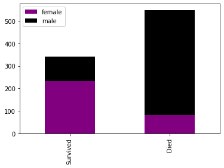

```python
plot_by_surv_died(train_df, 'Sex')
```

```python
print(f'---> Survive ʕ-ᴥ-ʔ <---\n\n{survive}')
```

```
---> Survive ʕ-ᴥ-ʔ <---

female    233
male      109
Name: Sex, dtype: int64
```

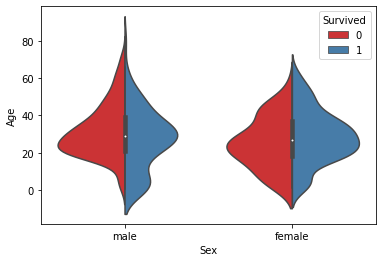

```python
sns.violinplot(x='Sex', y='Age', hue='Survived', data=train_df, split=True, palette='Set1')
```

It's interesting to see how in men case the difference of surviving probabilities had reduced in base on how old they were, more specifically, men between 20's 35's tended to survive more than older men (40's - 80's). By the other hand, in the women case they survived compararively well on all the age groups.

Now, why not try to visualice if there ir an corelation between ticket `fare` and probabilities to survive? In this case we could imagine these probabilities are based on their position on the ship or their priority to be rescued.

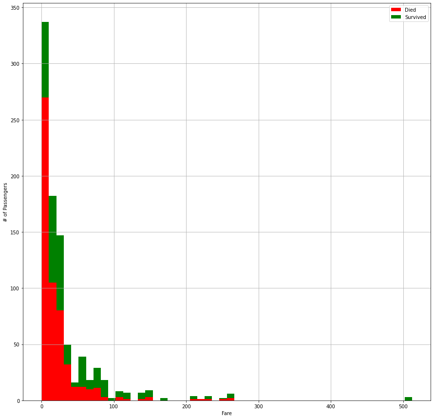

```python
figure = plt.figure(figsize=(15,15))
plt.hist([train_df[train_df['Survived']==0]['Fare'],
          train_df[train_df['Survived']==1]['Fare']],
         stacked=True,
         color = ['Red','Green'],
         bins = 50,
         label = ['Died', 'Survived']
        )
plt.xlabel('Fare')
plt.grid()
plt.ylabel('# of Passengers')
plt.legend()
```

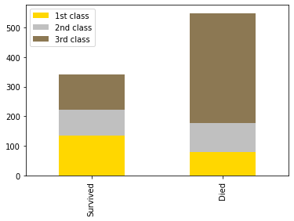

```python
plot_by_surv_died(train_df, 'Pclass', colors_=['#FFD700','#C0C0C0','#8C7853'])
plt.legend(['1st class','2nd class','3rd class'])
```

Despite of there was a very little part of expensive tickets passengers, the most part of them survived. By the other hand, more than half people who bought the cheapest tickets died. Were there a kind of priority of rescue based on their social status, or it's more kind of a statistical mean based on the quantity of passengers in each fare kind?

## Removing missing values and unnecessary data 🔨

Next, we'll return to check our missing data before to remove unnecessary variables.

```python
train_df.info()
```

```
<class 'pandas.core.frame.DataFrame'>
RangeIndex: 891 entries, 0 to 890
Data columns (total 12 columns):
 #   Column       Non-Null Count  Dtype
---  ------       --------------  -----
 0   PassengerId  891 non-null    int64
 1   Survived     891 non-null    int64
 2   Pclass       891 non-null    int64
 3   Name         891 non-null    object
 4   Sex          891 non-null    object
 5   Age          714 non-null    float64
 6   SibSp        891 non-null    int64
 7   Parch        891 non-null    int64
 8   Ticket       891 non-null    object
 9   Fare         891 non-null    float64
 10  Cabin        204 non-null    object
 11  Embarked     889 non-null    object
dtypes: float64(2), int64(5), object(5)
memory usage: 83.7+ KB
```

```python
print(train_df.isnull())
```

```
     PassengerId  Survived  Pclass   Name    Sex    Age  SibSp  Parch  Ticket  \
0          False     False   False  False  False  False  False  False   False
1          False     False   False  False  False  False  False  False   False
2          False     False   False  False  False  False  False  False   False
3          False     False   False  False  False  False  False  False   False
4          False     False   False  False  False  False  False  False   False
..           ...       ...     ...    ...    ...    ...    ...    ...     ...
886        False     False   False  False  False  False  False  False   False
887        False     False   False  False  False  False  False  False   False
888        False     False   False  False  False   True  False  False   False
889        False     False   False  False  False  False  False  False   False
890        False     False   False  False  False  False  False  False   False

      Fare  Cabin  Embarked
0    False   True     False
1    False  False     False
2    False   True     False
3    False  False     False
4    False   True     False
..     ...    ...       ...
886  False   True     False
887  False  False     False
888  False   True     False
889  False  False     False
890  False   True     False

[891 rows x 12 columns]
```

Print which columns have null (Zero or NaN) values.

```python
print(train_df.isnull().any())
```

```
PassengerId    False
Survived       False
Pclass         False
Name           False
Sex            False
Age             True
SibSp          False
Parch          False
Ticket         False
Fare           False
Cabin           True
Embarked        True
dtype: bool
```

```python
def plotting_missing_data(dataset):
    # Conf
    fig, ax = plt.subplots(figsize=(5,5))
    plt.title('Missing data')
    # Hearmap without color bar
    sns.heatmap(dataset.isnull(), cbar=False,
                cmap=sns.color_palette("rocket_r", as_cmap=True) )
```

We have some missing values on `Age`, `Cabin` and `Embarked`. Let's to visualize it:

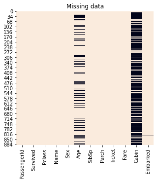

```python
plotting_missing_data(train_df)
```

but first of all, let's try to convert our values `male`, `female` into 0, 1.

We will use class `sklearn.preprocessing.LabelEncoder` which encode target labels with value between 0 and n_classes-1; in this case, between $0$ and $1$.

```python
label_encoder = preprocessing.LabelEncoder()
encoder_sex = label_encoder.fit_transform(train_df['Sex'])
train_df['Sex'] = encoder_sex
train_df.head(5)
```

|  | PassengerId | Survived | Pclass | Name | Sex | Age | SibSp | Parch | Ticket | Fare | Cabin | Embarked |
| --- | --- | --- | --- | --- | --- | --- | --- | --- | --- | --- | --- | --- |
| 0 | 1 | 0 | 3 | Braund, Mr. Owen Harris | 1 | 22.0 | 1 | 0 | A/5 21171 | 7.2500 | NaN | S |
| 1 | 2 | 1 | 1 | Cumings, Mrs. John Bradley (Florence Briggs Th... | 0 | 38.0 | 1 | 0 | PC 17599 | 71.2833 | C85 | C |
| 2 | 3 | 1 | 3 | Heikkinen, Miss. Laina | 0 | 26.0 | 0 | 0 | STON/O2. 3101282 | 7.9250 | NaN | S |
| 3 | 4 | 1 | 1 | Futrelle, Mrs. Jacques Heath (Lily May Peel) | 0 | 35.0 | 1 | 0 | 113803 | 53.1000 | C123 | S |
| 4 | 5 | 0 | 3 | Allen, Mr. William Henry | 1 | 35.0 | 0 | 0 | 373450 | 8.0500 | NaN | S |

```python
label_encoder_test= preprocessing.LabelEncoder()
encoder_sex_test = label_encoder_test.fit_transform(test_df['Sex'])
test_df['Sex'] = encoder_sex_test
test_df.head(5)
```

|  | PassengerId | Pclass | Name | Sex | Age | SibSp | Parch | Ticket | Fare | Cabin | Embarked |
| --- | --- | --- | --- | --- | --- | --- | --- | --- | --- | --- | --- |
| 0 | 892 | 3 | Kelly, Mr. James | 1 | 34.5 | 0 | 0 | 330911 | 7.8292 | NaN | Q |
| 1 | 893 | 3 | Wilkes, Mrs. James (Ellen Needs) | 0 | 47.0 | 1 | 0 | 363272 | 7.0000 | NaN | S |
| 2 | 894 | 2 | Myles, Mr. Thomas Francis | 1 | 62.0 | 0 | 0 | 240276 | 9.6875 | NaN | Q |
| 3 | 895 | 3 | Wirz, Mr. Albert | 1 | 27.0 | 0 | 0 | 315154 | 8.6625 | NaN | S |
| 4 | 896 | 3 | Hirvonen, Mrs. Alexander (Helga E Lindqvist) | 0 | 22.0 | 1 | 1 | 3101298 | 12.2875 | NaN | S |

In this case we have, `men` =1 and `female` = 0.

```python
train['Age'] = train['Age'].fillna(train['Age'].median())
print(train_df.isnull().any())
```

```
PassengerId    False
Survived       False
Pclass         False
Name           False
Sex            False
Age            False
SibSp          False
Parch          False
Ticket         False
Fare           False
Cabin           True
Embarked        True
dtype: bool
```

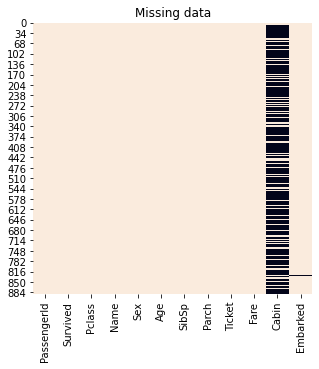

```python
plotting_missing_data(train_df)
```

Then, let's do something similar with categorical data (`Cabin` and `Embarked`). We'll start with `Embarked` because there are very few non values:

```python
train_df['Embarked'].isnull().sum()
```

```
2
```

There are only 2 non values, so, we'll fill there with a 'S' value:

```python
train_df['Embarked'] = train_df['Embarked'].fillna('S')
```

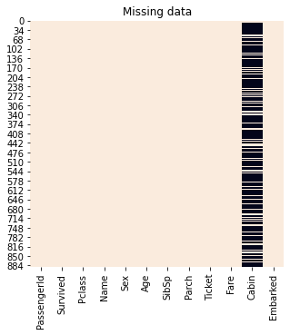

```python
plotting_missing_data(train_df)
```

The last one, is our Cabin column. In this case we have a lot of missing values so, trying to not change our data, we will replace the missing cabbing with letter U referring to `Unknown`.

```python
train_df['Cabin'] = train_df['Cabin'].fillna('U')
```

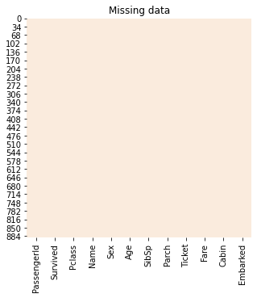

```python
plotting_missing_data(train_df)
```

#### The same process in test data:

```python
print(test_df.isnull().any())
```

```
PassengerId    False
Pclass         False
Name           False
Sex            False
Age             True
SibSp          False
Parch          False
Ticket         False
Fare            True
Cabin           True
Embarked       False
dtype: bool
```

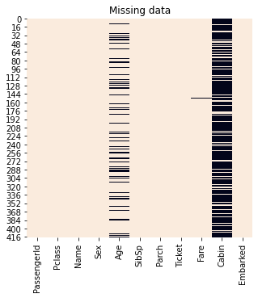

```python
plotting_missing_data(test_df)
```

```python
test_df['Age'] = test_df['Age'].fillna(test_df['Age'].median())
```

```python
test_df['Fare'] = test_df['Fare'].fillna(test_df['Fare'].median())
```

```python
test_df['Cabin'] = test_df['Cabin'].fillna('U')
```

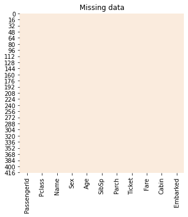

```python
plotting_missing_data(test_df)
```

## Processing data ⚙

```python
train_df
```

|  | PassengerId | Survived | Pclass | Name | Sex | Age | SibSp | Parch | Ticket | Fare | Cabin | Embarked |
| --- | --- | --- | --- | --- | --- | --- | --- | --- | --- | --- | --- | --- |
| 0 | 1 | 0 | 3 | Braund, Mr. Owen Harris | 1 | 22.0 | 1 | 0 | A/5 21171 | 7.2500 | U | S |
| 1 | 2 | 1 | 1 | Cumings, Mrs. John Bradley (Florence Briggs Th... | 0 | 38.0 | 1 | 0 | PC 17599 | 71.2833 | C85 | C |
| 2 | 3 | 1 | 3 | Heikkinen, Miss. Laina | 0 | 26.0 | 0 | 0 | STON/O2. 3101282 | 7.9250 | U | S |
| 3 | 4 | 1 | 1 | Futrelle, Mrs. Jacques Heath (Lily May Peel) | 0 | 35.0 | 1 | 0 | 113803 | 53.1000 | C123 | S |
| 4 | 5 | 0 | 3 | Allen, Mr. William Henry | 1 | 35.0 | 0 | 0 | 373450 | 8.0500 | U | S |
| ... | ... | ... | ... | ... | ... | ... | ... | ... | ... | ... | ... | ... |
| 886 | 887 | 0 | 2 | Montvila, Rev. Juozas | 1 | 27.0 | 0 | 0 | 211536 | 13.0000 | U | S |
| 887 | 888 | 1 | 1 | Graham, Miss. Margaret Edith | 0 | 19.0 | 0 | 0 | 112053 | 30.0000 | B42 | S |
| 888 | 889 | 0 | 3 | Johnston, Miss. Catherine Helen "Carrie" | 0 | 28.0 | 1 | 2 | W./C. 6607 | 23.4500 | U | S |
| 889 | 890 | 1 | 1 | Behr, Mr. Karl Howell | 1 | 26.0 | 0 | 0 | 111369 | 30.0000 | C148 | C |
| 890 | 891 | 0 | 3 | Dooley, Mr. Patrick | 1 | 32.0 | 0 | 0 | 370376 | 7.7500 | U | Q |

891 rows × 12 columns

```python
test_df
```

|  | PassengerId | Pclass | Name | Sex | Age | SibSp | Parch | Ticket | Fare | Cabin | Embarked |
| --- | --- | --- | --- | --- | --- | --- | --- | --- | --- | --- | --- |
| 0 | 892 | 3 | Kelly, Mr. James | 1 | 34.5 | 0 | 0 | 330911 | 7.8292 | U | Q |
| 1 | 893 | 3 | Wilkes, Mrs. James (Ellen Needs) | 0 | 47.0 | 1 | 0 | 363272 | 7.0000 | U | S |
| 2 | 894 | 2 | Myles, Mr. Thomas Francis | 1 | 62.0 | 0 | 0 | 240276 | 9.6875 | U | Q |
| 3 | 895 | 3 | Wirz, Mr. Albert | 1 | 27.0 | 0 | 0 | 315154 | 8.6625 | U | S |
| 4 | 896 | 3 | Hirvonen, Mrs. Alexander (Helga E Lindqvist) | 0 | 22.0 | 1 | 1 | 3101298 | 12.2875 | U | S |
| ... | ... | ... | ... | ... | ... | ... | ... | ... | ... | ... | ... |
| 413 | 1305 | 3 | Spector, Mr. Woolf | 1 | 27.0 | 0 | 0 | A.5. 3236 | 8.0500 | U | S |
| 414 | 1306 | 1 | Oliva y Ocana, Dona. Fermina | 0 | 39.0 | 0 | 0 | PC 17758 | 108.9000 | C105 | C |
| 415 | 1307 | 3 | Saether, Mr. Simon Sivertsen | 1 | 38.5 | 0 | 0 | SOTON/O.Q. 3101262 | 7.2500 | U | S |
| 416 | 1308 | 3 | Ware, Mr. Frederick | 1 | 27.0 | 0 | 0 | 359309 | 8.0500 | U | S |
| 417 | 1309 | 3 | Peter, Master. Michael J | 1 | 27.0 | 1 | 1 | 2668 | 22.3583 | U | C |

418 rows × 11 columns

Before that, we can obviate some parameters that we are sure that cannot affect our predictions, like name, ticket number, etc and the variable that we want to predict `Survived` to can compare later our model fit:

```python
train_predictors = train_df.drop(['Name', 'PassengerId', 'Survived', 'Cabin', 'Ticket'], axis = 1) #Axis = 1 refers to Columns
test_predictors =  test_df.drop(['Name', 'PassengerId', 'Cabin', 'Ticket'], axis = 1)
```

```python
categorical = [i for i in train_predictors.columns if
               train_predictors[i].nunique() and
               train_predictors[i].dtype == 'object']


categorical2 = [i for i in test_predictors.columns if
               test_predictors[i].nunique() and
               test_predictors[i].dtype == 'object']
categorical
```

```
['Embarked']
```

```python
categorical2
```

```
['Embarked']
```

```python
numerical = [i for i in train_predictors.columns if
             train_predictors[i].dtype in ['int64','float64']
            ]
numerical
```

```
['Pclass', 'Sex', 'Age', 'SibSp', 'Parch', 'Fare']
```

Then, we need to decompose our categorical variable into numeric using `.get_dummies()`, which convert categorical variable into dummy/indicator variables.

```python
dummy_encoded_train_predictors = pd.get_dummies(train_predictors)
dummy_encoded_train_predictors
```

|  | Pclass | Sex | Age | SibSp | Parch | Fare | Embarked_C | Embarked_Q | Embarked_S |
| --- | --- | --- | --- | --- | --- | --- | --- | --- | --- |
| 0 | 3 | 1 | 22.0 | 1 | 0 | 7.2500 | 0 | 0 | 1 |
| 1 | 1 | 0 | 38.0 | 1 | 0 | 71.2833 | 1 | 0 | 0 |
| 2 | 3 | 0 | 26.0 | 0 | 0 | 7.9250 | 0 | 0 | 1 |
| 3 | 1 | 0 | 35.0 | 1 | 0 | 53.1000 | 0 | 0 | 1 |
| 4 | 3 | 1 | 35.0 | 0 | 0 | 8.0500 | 0 | 0 | 1 |
| ... | ... | ... | ... | ... | ... | ... | ... | ... | ... |
| 886 | 2 | 1 | 27.0 | 0 | 0 | 13.0000 | 0 | 0 | 1 |
| 887 | 1 | 0 | 19.0 | 0 | 0 | 30.0000 | 0 | 0 | 1 |
| 888 | 3 | 0 | 28.0 | 1 | 2 | 23.4500 | 0 | 0 | 1 |
| 889 | 1 | 1 | 26.0 | 0 | 0 | 30.0000 | 1 | 0 | 0 |
| 890 | 3 | 1 | 32.0 | 0 | 0 | 7.7500 | 0 | 1 | 0 |

891 rows × 9 columns

```python
dummy_encoded_test_predictors = pd.get_dummies(test_predictors)
dummy_encoded_test_predictors
```

|  | Pclass | Sex | Age | SibSp | Parch | Fare | Embarked_C | Embarked_Q | Embarked_S |
| --- | --- | --- | --- | --- | --- | --- | --- | --- | --- |
| 0 | 3 | 1 | 34.5 | 0 | 0 | 7.8292 | 0 | 1 | 0 |
| 1 | 3 | 0 | 47.0 | 1 | 0 | 7.0000 | 0 | 0 | 1 |
| 2 | 2 | 1 | 62.0 | 0 | 0 | 9.6875 | 0 | 1 | 0 |
| 3 | 3 | 1 | 27.0 | 0 | 0 | 8.6625 | 0 | 0 | 1 |
| 4 | 3 | 0 | 22.0 | 1 | 1 | 12.2875 | 0 | 0 | 1 |
| ... | ... | ... | ... | ... | ... | ... | ... | ... | ... |
| 413 | 3 | 1 | 27.0 | 0 | 0 | 8.0500 | 0 | 0 | 1 |
| 414 | 1 | 0 | 39.0 | 0 | 0 | 108.9000 | 1 | 0 | 0 |
| 415 | 3 | 1 | 38.5 | 0 | 0 | 7.2500 | 0 | 0 | 1 |
| 416 | 3 | 1 | 27.0 | 0 | 0 | 8.0500 | 0 | 0 | 1 |
| 417 | 3 | 1 | 27.0 | 1 | 1 | 22.3583 | 1 | 0 | 0 |

418 rows × 9 columns

#### Testing with local data

```python
y_target = train_df['Survived'].values
```

```python
x_features_one = dummy_encoded_train_predictors
x_features_one
```

|  | Pclass | Sex | Age | SibSp | Parch | Fare | Embarked_C | Embarked_Q | Embarked_S |
| --- | --- | --- | --- | --- | --- | --- | --- | --- | --- |
| 0 | 3 | 1 | 22.0 | 1 | 0 | 7.2500 | 0 | 0 | 1 |
| 1 | 1 | 0 | 38.0 | 1 | 0 | 71.2833 | 1 | 0 | 0 |
| 2 | 3 | 0 | 26.0 | 0 | 0 | 7.9250 | 0 | 0 | 1 |
| 3 | 1 | 0 | 35.0 | 1 | 0 | 53.1000 | 0 | 0 | 1 |
| 4 | 3 | 1 | 35.0 | 0 | 0 | 8.0500 | 0 | 0 | 1 |
| ... | ... | ... | ... | ... | ... | ... | ... | ... | ... |
| 886 | 2 | 1 | 27.0 | 0 | 0 | 13.0000 | 0 | 0 | 1 |
| 887 | 1 | 0 | 19.0 | 0 | 0 | 30.0000 | 0 | 0 | 1 |
| 888 | 3 | 0 | 28.0 | 1 | 2 | 23.4500 | 0 | 0 | 1 |
| 889 | 1 | 1 | 26.0 | 0 | 0 | 30.0000 | 1 | 0 | 0 |
| 890 | 3 | 1 | 32.0 | 0 | 0 | 7.7500 | 0 | 1 | 0 |

891 rows × 9 columns

```python
x_train, x_validation, y_train, y_validation = train_test_split(x_features_one, y_target,
                                                                 test_size = 0.25, random_state=1)
```

```python
tree_one = tree.DecisionTreeClassifier()
```

```python
tree_one = tree_one.fit(x_train, y_train)
```

```python
tree_one_accuracy = round(tree_one.score(x_validation, y_validation), 3)
tree_one_accuracy
```

```
0.758
```

## Creating model 🧠

```python
from xgboost import XGBRegressor #pip install xgboost
from sklearn.metrics import r2_score
```

```python
X_train = dummy_encoded_train_predictors
```

```python
y_train = train_df['Survived'].values
```

```python
X_test = dummy_encoded_test_predictors
```

```python
model = tree.DecisionTreeClassifier()
```

```python
model.fit(X_train, y_train)
```

```
DecisionTreeClassifier()
```

```python
predictions = model.predict(X_test)
```

```python
output = pd.DataFrame({'PassengerId': test_df.PassengerId, 'Survived': predictions})
output.to_csv('my_submission.csv', index=False)
print("Your submission was successfully saved!")
```

```
Your submission was successfully saved!
```